# Synthetic data example for BayesNSGP with the gp2Scale likelihood

Mark Risser

20 Feb 2024

In order to demonstrate how one can use the gp2Scale likelihood option within BayesNSGP, we provide code to draw data from a ground truth function and subsequently conduct inference for a small, one-dimensional simulated data set. Here we use the test case described in Section 4.1 of Risser, Noack, and Luo (2024+).

The synthetic data test proceeds as follows. First, we suppose the ground truth function is a piecewise-constant function on the unit interval, defined as
$$y(x) = \left\{ \begin{array}{cc}
-1 & \text{if } x \leq 0.25 \text{ or } 0.5 < x \leq 0.75 \\
1 & \text{if } 0.25 < x \leq 0.5 \text{ or } x > 0.75,
\end{array}\right.$$
and we have $N=50$ noisy measurements from this function for training a Gaussian process. The form of this ground truth function suggests that there should be two sets of two bump functions: $y(x)$ is perfectly correlated in $(0,0.25]$ and $(0.5,0.75]$; furthermore, $y(x)$ is perfectly correlated in $(0.25,0.5]$ and $(0.75,1)$. In other words, $n_1=2$ and $n_2=2$. We then fit our proposed kernel to the noisy data assuming we know nothing about its ground truth. When fitting, we suppose the core kernel is a stationary Mat'ern with smoothness $\nu=2.5$.

Here, we set up the inputs and draw noisy data from the ground truth function:

```r
f_ytrue <- function(x, a = -1, b = 1){
  y <- rep(0,length(x))
  y[x < 1/4] <- a
  y[x >= 1/4 & x < 1/2] <- b
  y[x >= 1/2 & x < 3/4] <- a
  y[x >= 3/4] <- b
  return(y)
}

N_train <- 50
N_test <- 100
xmin <- 0
xmax <- 1
d <- 1
x_test <- matrix(seq(from = xmin + 1/78, to = xmax - 1/78, length=N_test), ncol = 1)
x_train <- matrix(seq(from=xmin, to = xmax, length=N_train), ncol = 1)
x_all <- rbind(x_train, x_test)
dist_all <- as.matrix(dist(x_all))
dists <- nsDist(x_all, isotropic = TRUE)

# Set up constants and design matrices
coords <- as.matrix(x_train)
N <- N_train
# Prediction grid
predCoords <- x_test

# Draw true function and noisy data
y <- f_ytrue(x_all)
set.seed(011)
z <- as.numeric(y[1:N_train] + rnorm(N_train, sd = 0.075))
```

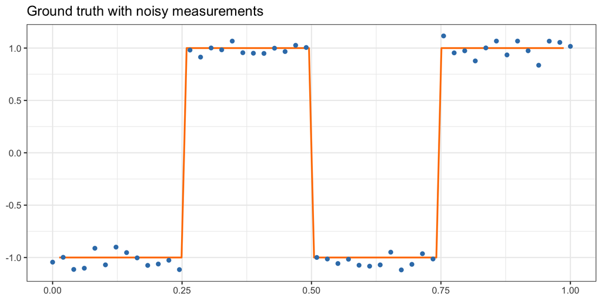

```r
ggplot() + labs(x = NULL, y = NULL) +
  geom_line(data = data.frame(x = x_test, y = y[-(1:N_train)]),
            mapping = aes(x = x, y = y), color = brewer.pal(6, "Set1")[5], linewidth = 0.8) +
  geom_point(data = data.frame(x = x_train, z = z),
             mapping = aes(x = x, y = z), size = 1.5, color = brewer.pal(6, "Set1")[2]) +
  theme_bw() + theme(legend.position = "none") +
  ggtitle("Ground truth with noisy measurements")
```

### Model and MCMC setup

We now want to fit the gp2Scale likelihood with a given number of bump functions (for now $n_1=4$ and $n_2=4$) with a stationary core kernel. The required constants can be set up as

```r
# Constants
n1 <- 4
n2 <- 4
# Randomly initialize bump function locations.
# Must be a matrix of size n2*d x n1
bumpLocs_init <- matrix(runif(n1*n2*d), ncol = n1)
constants <- list(
  nu = 2.5,             # Matern smoothness
  tau_HP1 = 10,         # Prior upper bound for noise variance
  sigma_HP1 = 10,       # Prior upper bound for core kernel signal var.
  Sigma_HP1 = 100,      # Prior upper bound for core kernel length-scale
  dists = as.matrix(dist(coords)),
  n1 = n1, n2 = n2,
  bumpLocs_init = bumpLocs_init,
  normalize = 1,        # Should sparse kernel have 1's on diagonal
  bumps_HP = c(1/4,     # Prior upper bound on bump func radii
               3/10,    # Prior upper bound on compactly supp radius
               100)     # Prior upper bound on compactly supp scale
)
```

and we can build the model with

```r
Rmodel <- nsgpModel(
          likelihood = "gp2Scale",           # Likelihood model
          constants = constants,             # Necessary constants (hyperparams, etc.)
          coords = coords, data = z,         # coords = input locations; data
          sparse_model = "bumpPlusSparse",   # Model for sparsity
          Sigma_model = "constantIso",       # Stat model for anisotropy (Iso = isotropic)
          sigma_model = "constant",          # Stat model for signal variance
          tau_model = "constant",            # Stat model for noise variance
          mu_model = "constant"              # Prior mean
        )
```

```
## as(<dtCMatrix>, "dgTMatrix") is deprecated since Matrix 1.5-0; do as(as(., "generalMatrix"), "TsparseMatrix") instead
```

Once the model has been built, the first step is to configure the MCMC:

```r
conf <- configureMCMC(Rmodel)
```

The default samplers can be queried with:

```r
conf$printSamplers()
```

```
## [1]  RW sampler: alpha
## [2]  RW sampler: delta
## [3]  RW sampler: Sigma_coef1
## [4]  RW sampler: rads[1, 1]
## [5]  RW sampler: rads[1, 2]
## [6]  RW sampler: rads[1, 3]
## [7]  RW sampler: rads[1, 4]
## [8]  RW sampler: rads[2, 1]
## [9]  RW sampler: rads[2, 2]
## [10] RW sampler: rads[2, 3]
## [11] RW sampler: rads[2, 4]
## [12] RW sampler: rads[3, 1]
## [13] RW sampler: rads[3, 2]
## [14] RW sampler: rads[3, 3]
## [15] RW sampler: rads[3, 4]
```

[output cut: 55 more lines]

from which we can see that by default most parameters have been assigned univariate random walk samplers, except for the amplitudes `ampls[]`, which have been assigned a binary sampler which, per the documentation, “performs Gibbs sampling for binary-valued (discrete 0/1) nodes.” One of the main benefits of using **nimble** is that it is very easy to group univariate samplers into a single block sampler, or alternatively to swap in different sampler types. To reconfigure some of these default samplers, first remove the existing samplers via

```r
conf$removeSamplers(c("alpha","Sigma_coef1","rads[]","bumpLocs[]","r0","s0","pi[]"))
```

and then gradually reassign samplers as needed. For our example, it works well to block the hyperparameters for each bump function, as well as the compactly supported and core hyperparameters:

```r
for(j in 1:n1){
  for(k in 1:n2){
    conf$addSampler(target = c(paste0(c("rads["),j,", ",k,"]"),
                               paste0(c("pi["),j,", ",k,"]"),
                               paste0("bumpLocs[",k,", ",j,"]")),
                    type = "RW_block", silent = TRUE)
  }
}
conf$addSampler(target = c("r0","s0"), type = "RW_block", silent = TRUE)
conf$addSampler(target = c("alpha","Sigma_coef1"), type = "RW_block", silent = TRUE)
```

The final configuration is then:

```r
conf$printSamplers()
```

```
## [1]  RW sampler: delta
## [2]  RW sampler: beta
## [3]  binary sampler: ampls[1, 1]
## [4]  binary sampler: ampls[1, 2]
## [5]  binary sampler: ampls[1, 3]
## [6]  binary sampler: ampls[1, 4]
## [7]  binary sampler: ampls[2, 1]
## [8]  binary sampler: ampls[2, 2]
## [9]  binary sampler: ampls[2, 3]
## [10] binary sampler: ampls[2, 4]
## [11] binary sampler: ampls[3, 1]
## [12] binary sampler: ampls[3, 2]
## [13] binary sampler: ampls[3, 3]
## [14] binary sampler: ampls[3, 4]
## [15] binary sampler: ampls[4, 1]
```

[output cut: 21 more lines]

### Run the MCMC

Once the samplers have been sufficiently modified, we can then build the MCMC, compile the model, and compile the MCMC as follows:

```r
Rmcmc <- buildMCMC(conf) # Build the MCMC
Cmodel <- compileNimble(Rmodel) # Compile the model in C++
Cmcmc <- compileNimble(Rmcmc, project = Rmodel) # Compile the MCMC in C++
```

Finally, the MCMC can be run for, say, 20000 iterations (with 10000 discarded as burn-in and storing every tenth sample) using:

```r
samples <- runMCMC(Cmcmc, niter = 20000, nburnin = 10000, thin = 10)
```

The `runMCMC` function is a **nimble** function designed to take an MCMC algorithm and run the MCMC with one or more chains, with optional arguments to burn-in or thin the output (for further information, we refer the reader to the **nimble** help files).

### Posterior summaries

The `samples` object from `runMCMC` is a matrix with one row for each saved MCMC sample (1000 total, thinned from the 10000 post burn-in) and one column for each sampled parameter:

```r
dim(samples)
```

```
## [1] 1000   70
```

```r
head(samples[,1:12])
```

```
##      Sigma_coef1     alpha ampls[1, 1] ampls[2, 1] ampls[3, 1] ampls[4, 1]
## [1,]    75.15237 1.1226498           0           0           0           1
## [2,]    72.25102 0.7081787           0           0           0           1
## [3,]    95.28299 0.5148996           0           0           0           1
## [4,]    81.34927 1.4986299           0           0           0           1
## [5,]    98.74240 0.2640302           0           0           0           1
## [6,]    85.15506 1.1755021           0           1           0           1
##      ampls[1, 2] ampls[2, 2] ampls[3, 2] ampls[4, 2] ampls[1, 3] ampls[2, 3]
## [1,]           0           1           0           1           0           0
## [2,]           0           1           0           1           0           0
## [3,]           0           1           0           1           0           0
## [4,]           0           1           0           1           0           0
## [5,]           0           1           0           1           0           0
## [6,]           0           1           0           1           0           1
```

We can then summarize the bump functions:

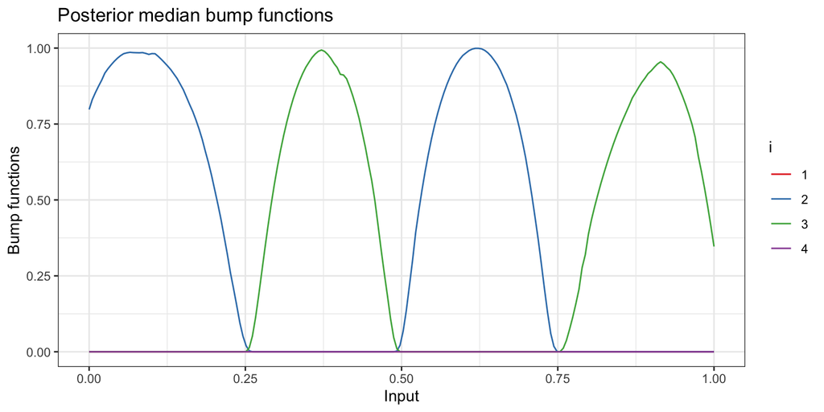

```r
# Summarize bump functions
f_bumps <- function(samps, n1, n2, xtest = matrix(seq(from=0,to=1,length=200), ncol = 1)){
  bump_true <- array(NA, dim = c(n1, length(xtest)))
  for(j in 1:n1) {
    g_j <- nimRep(0, length(xtest))
    for (b in 1:n2) {
      tmp <- nimRep(0, 200)
      for (l in 1:d) {
        rwix <- (n2 * (l - 1) + b)
        tmp <- tmp + (xtest[, l] - rep(samps[paste0("bumpLocs[", rwix, ", ", j,"]")], length(xtest)))^2
      }
      dist_jb <- sqrt(tmp)
      ind_nz <- which(dist_jb <= samps[paste0("rads[", j, ", ", b,"]")])
      g_j[ind_nz] <- g_j[ind_nz] + as.numeric(samps[paste0("ampls[", j, ", ", b,"]")] > 0) * exp(1 - 1/(1 - dist_jb[ind_nz]^2/samps[paste0("rads[", j, ", ", b,"]")]^2))
    }
    bump_true[j,] <- g_j
  }
  return(bump_true)
}

# Calculate posteriors
bump_postmed <- NULL
bumps_post <- array(NA,dim=c(n1,200,1000))
for(j in 1:1000){
  bumps_post[,,j] <- f_bumps(samples[j,], n1, n2)
}
# Calculate posterior median
for(i in 1:n1){
  df <- data.frame(
    n1 = i,
    x = matrix(seq(from=0,to=1,length=200)),
    fi = apply(bumps_post[i,,], 1, median)
  )
  bump_postmed <- rbind(bump_postmed, df)
}
ggplot(bump_postmed, aes(x = x, y = fi, color = as.factor(n1))) + geom_line() +
  theme_bw() + scale_color_manual(values=brewer.pal(4,"Set1"), name = "i") +
  labs(x = "Input", y = "Bump functions") +
  ggtitle("Posterior median bump functions")
```

and posterior correlation / covariance:

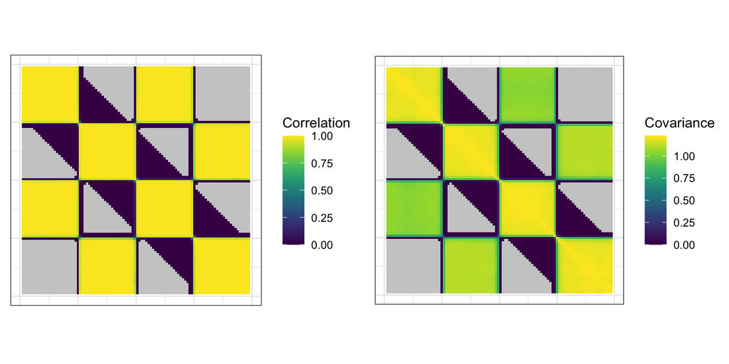

```r
dist_test <- as.matrix(dist(x_test))
dists_ns_test <- nsDist(x_test, isotropic = TRUE)
cov_post <- cor_post <- array(0, dim = c(100,100,1000))
for(j in 1:1000){
  c_j <- Cy_dm(  # Generate the kernel in dense format
      dists = dist_test, coords = x_test, N = nrow(x_test),
      d = 1, n1 = n1, n2 = n2, r0 = samples[j,"r0"], s0 = samples[j,"s0"],
      cstat_opt = 4, normalize = 1,
      bumpLocs = matrix(samples[j,sapply(str_split(colnames(samples), "\\["), function(x){x[1]}) == "bumpLocs"],
                        nrow = n2, ncol = n1), # array of bump function locations (n2*d x n1)
      rads = matrix(samples[j,sapply(str_split(colnames(samples), "\\["), function(x){x[1]}) == "rads"],
                    nrow = n1, ncol = n2),
      ampls = matrix(samples[j,sapply(str_split(colnames(samples), "\\["), function(x){x[1]}) == "ampls"],
                     nrow = n1, ncol = n2),
      shps = matrix(1, nrow = n1, ncol = n2), # matrix of radii, amplitudes, shapes (n1 x n2)
      dist1_sq = dists_ns_test$dist1_sq, dist2_sq = dists_ns_test$dist2_sq, dist12 = dists_ns_test$dist12,
      Sigma11 = rep(samples[j,"Sigma_coef1"], 100),
      Sigma22 = rep(samples[j,"Sigma_coef1"], 100), Sigma12 = rep(0,100),
      nu = 2.5, log_sigma_vec = rep(log(sqrt(samples[j,"alpha"])), 100),
      lognuggetSD = rep(log(sqrt(samples[j,"delta"])), 100)
    )
  cor_post[,,j] <- diag(1/sqrt(diag(c_j))) %*% c_j %*% diag(1/sqrt(diag(c_j)))
  cov_post[,,j] <- c_j
}

cov_postmed <- apply(cov_post, 1:2, median)
cor_postmed <- apply(cor_post, 1:2, median)
df <- expand.grid(x1 = (as.numeric(x_test)), x2 = rev(as.numeric(x_test)))
df$covmed <- c(cov_postmed)
df$cormed <- c(cor_postmed)
df$covmed[df$covmed == 0] <- NA
df$cormed[df$cormed == 0] <- NA

grid.arrange(
  ggplot(df, aes(x = x1, y = x2, fill = cormed)) + geom_tile() +
    theme_bw() + labs(x = NULL, y = NULL) +
    scale_fill_gradientn(colors = viridis_pal(option = "viridis")(8), name = "Correlation",
                         breaks = c(0,0.25,0.5,0.75,1), limits = c(0,1),
                         na.value = "gray80") + coord_fixed() +
    theme(axis.text = element_blank(), axis.ticks = element_blank(),
          strip.text = element_text(size=12)),
  ggplot(df, aes(x = x1, y = x2, fill = covmed)) + geom_tile() +
    theme_bw() + labs(x = NULL, y = NULL) +
    scale_fill_gradientn(colors = viridis_pal(option = "viridis")(8), name = "Covariance",
                         breaks = c(0,0.25,0.5,0.75,1,1.25,1.5), limits = c(0,max(df$covmed)),
                         na.value = "gray80") + coord_fixed() +
    theme(axis.text = element_blank(), axis.ticks = element_blank(),
          strip.text = element_text(size=12)),
  nrow = 1
)
```

### Posterior prediction

Using `samples`, the matrix of posterior samples generated from the MCMC, we can proceed with posterior prediction as follows:

```r
# Predictions
pred <- nsgpPredict(model = Rmodel, samples = samples, coords.predict = predCoords )
```

Finally, we can plot the predictions with uncertainty:

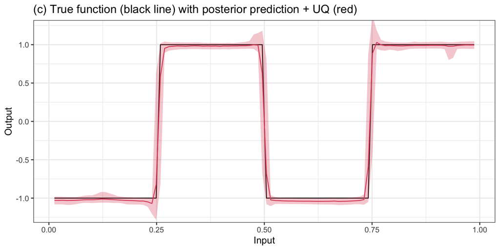

```r
pred_df <- data.frame(
  x = predCoords[,1], y = y[-(1:N_train)],
  yhat = colMeans(pred$pred, na.rm = T),
  ylb = apply(pred$pred, 2, quantile, probs = 0.025, na.rm = T),
  yub = apply(pred$pred, 2, quantile, probs = 0.975, na.rm = T),
  ysd = apply(pred$pred, 2, sd, na.rm = T)
)

ggplot() +
  geom_line(data = pred_df, mapping = aes(x = x, y = y)) +
  geom_line(data = pred_df, mapping = aes(x = x, y = yhat), col = 2) +
  geom_ribbon(data = pred_df, mapping = aes(x = x, ymin = ylb, ymax = yub), fill = 2, alpha = 0.3)  +
  theme_bw() + coord_cartesian(ylim=c(-1.2,1.2)) +
  ggtitle("(c) True function (black line) with posterior prediction + UQ (red)") +
  labs(x = "Input", y = "Output")
```